# Data606_hw8_weizhou

Wei Zhou

5/5/2019

## Exercise 8.2 Baby weights, Part II

#### a. Write the equation of the regression line.

y_hat = 120.07 - 1.93 * parity

#### b. Interpret the slope in this context, and calculate the predicted birth weight of first borns and others.

If parity is 1 which means the child is not the first born, we would expect 1.93 oz. lower birth weight than first born child.

#### c. Is there a statistically significant relationship between the average birth weight and parity?

Since the pvalue is >= 0.05, there is no statistically significant relationship between the average birth weight and parity.

## Exercise 8.4 Absenteeism

#### (a) Write the equation of the regression line.

ŷ =18.93−9.11×eth+3.10×sex+2.15×lrn

#### (c)Calculate the residual for the first observation in the data set: a student who is aboriginal, male, a slow learner, and missed 2 days of school.

```r
y = 18.93 - 9.11 * 0 + 3.10 * 1 + 2.15 * 1
residual = 2 - y
residual
```

```
## [1] -22.18
```

#### (d) The variance of the residuals is 240.57, and the variance of the number of absent days for all students in the data set is 264.17. Calculate the R2 and the adjusted R2. Note that there are 146 observations in the data set.

```r
r_sq = 1- 240.57 / 264.17
```

R^2 = 0.0893364

```r
adj_r_sq = 1- (240.57 / 264.17) * ((146-1)/(146-3-1))
adj_r_sq
```

```
## [1] 0.07009704
```

R^2_adjust = 0.070097

## Exercise 8.8 Absenteeism, Part II

#### a. Which, if any, variable should be removed from the model first?

Since removing the learner status has the highest adjusted R square, learnner status should be removed from the model first.

## Exercise 8.16 Challenger disaster, Part I

#### a. Each column of the table above represents a different shuttle mission. Examine these data and describe what you observe with respect to the relationship between temperatures and damaged O-rings.

The number of O-rings damaged seems to be strongly correlated with the temperature. The higher the temperature, the lower possibility the O - ring been damaged.

A negative slope indicates a negative association between temperature and damaged O-rings. The associate between temperature and o-ring damage is staticially significant.

#### c. Write out the logistic model using the point estimates of the model parameters.

log(p/(1-p)) = 11.663−0.2162×temperature

#### d. Based on the model, do you think concerns regarding O-rings are justified? Explain.

```r
P_50 =exp(11.663-0.2162*50)/(1+exp(11.663-0.2162*50))
```

According to the model, there will be a high chance of damaged rings under 50 degrees (0.7011961). Since O-rings are critical components to success, the concerns are justified

## Exercise 8.18 Challenger disaster, Part II

#### a. The data provided in the previous exercise are shown in the plot. The logistic model fit to these data may be written as

```r
p_dmg = function(temp){
  p=exp(11.663-0.2162*temp)/(1+exp(11.663-0.2162*temp))
  return(round(p,3))
}

temp_ls = seq(51,71,2)
probs = p_dmg(temp_ls)
result =data.frame(probs,temp_ls)
result
```

```
##    probs temp_ls
## 1  0.654      51
## 2  0.551      53
## 3  0.443      55
## 4  0.341      57
## 5  0.251      59
## 6  0.179      61
## 7  0.124      63
## 8  0.084      65
## 9  0.056      67
## 10 0.037      69
## 11 0.024      71
```

#### b. Add the model-estimated probabilities from part (a) on the plot, then connect these dots using a smooth curve to represent the model-estimated probabilities.

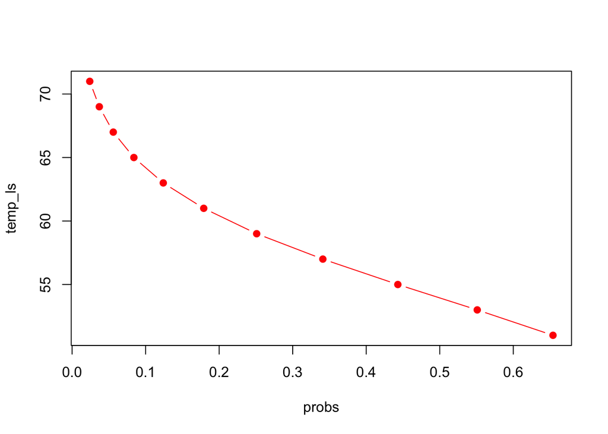

```r
plot(result, type = "b", pch = 19, col = "red")
```

#### c. Describe any concerns you may have regarding applying logistic regression in this application, and note any assumptions that are required to accept the model’s validity.

The conditions for this logistic regression are hard to check.